# Temperature-dependence of life history in an edible cricket: Implications for optimising mass rearing

- Show All Code
- Hide All Code
- View Source

Part 1: Effects of rearing temperature on life history from hatch to death

Author

Affiliation

Jacinta Kong

Department of Biology, Carleton Univeristy, Canada

Published

February 27, 2025

# 1 Aim

This experiment aimed to characterise the effects of rearing temperature on the life history of *Gryllodes sigillatus*, the banded cricket. This experiment is Part 1 of the paper *Temperature-dependence of life history in an edible cricket: Implications for optimising mass rearing*.

Personnel:

- Jacinta Kong
- Émile Vadboncoeur

## 1.1 Design

Ten temperatures 20 – 38 °C in 2 °C increments (Vevor incubators). Up to 24 crickets in each incubator reared from hatch to death. See main document for the full description.

## 1.2 Response variables

Measured weekly

- Survival (Section 3)
- Growth (Section 5)
- Adult mass (Section 6)
- Sex
- Instar
  - In this dataset, the adult stage is coded as the 8th instar to maintain a numeric variable.

# 2 Code setup

`tidyverse` for data wrangling and visualisation.  
`emmeans` for Tukey HSD post-hoc test.

```r
library(knitr)
opts_chunk$set(message = FALSE, warning = FALSE)
 # Data handling
library(tidyverse)
library(broom)
library(cowplot) # Plotting
library(emmeans) # Post hoc testing
options(tibble.width = Inf,
        pillar.sigfig = 5)

# Set plot themes
ggplot2::theme_set(theme_classic())
ggplot2::theme_update(text = element_text(size = 10),
                      panel.background = element_rect(fill = "transparent"),
                      plot.background = element_rect(fill = "transparent",
                                                     colour = NA),
                      legend.box.background = element_rect(fill = "transparent",
                                                           colour = NA),
                      legend.background = element_rect(fill = "transparent"),
                      strip.background = element_rect(fill = "transparent",
                                                      colour = NA),
                      strip.text = element_text(face = "bold")
)

# Colour palettes
temperature_pal <- viridisLite::viridis(end = 0.9, begin = 0.1, n = 10, option = "plasma")
```

## 2.1 Metadata

`tpc` contains the mass and demography data.

observation: unique observation number  
experiment: title of experiment (tpc)  
recorder: person recording observation (Émile or Jacinta)  
date: date measurement was taken  
incubator_number: identity number of incubator (MacMillan Lab)  
temperature: incubation temperature  
cricket: identification number of cricket  
instar: inferred instar based on morphology (1-8) where 8 is the adult stage  
sex: inferred sex based on morphology (Juvenile, Male, Female)  
container: mass of container without cricket (grams)  
cricket_container: weighing by difference method (grams)  
notes: other observations and corrections applied if any  
date_start: date cricket started the experiment (Day 0)  
date_six_instar: date cricket was first observed to have sex characteristics (6th instar)  
date_adult: date cricket was first observed to be adult date_removed: date cricket was removed from the experiment  
reason_removed: reason for why cricket was removed from the experiment (e.g. dead, escaped, missing)  
excluded: Is cricket excluded from analysis? Yes (1), No (0)  
reason_excluded: reason for why cricket was excluded from analysis (e.g. accidental death, missing)

```r
# Weekly mass
tpc <- read.csv("tpc/TPC_mass.csv") %>%
  mutate(mass = (cricket_container - container) * 1000,
         sex = factor(sex, levels = c("Juvenile", "Female", "Male")),
         date = as.POSIXct(date, format = "%d/%m/%Y"))

# Survival
tpc_survival <- read.csv("tpc/TPC_survival.csv") %>%
  # Format all date columns
  mutate(across(starts_with("date"), ~as.POSIXct(., format = "%d/%m/%Y")))

# Calculate days and weeks
tpc <- left_join(tpc, tpc_survival,
                 by = c("incubator_number" = "incubator_number",
                        "temperature" = "temperature",
                        "cricket" = "cricket"),
                 suffix = c(".y", "")) %>%
  mutate(experiment_day = as.numeric(
    difftime(date, date_start, units = "days")
  ),
  sex = ifelse(is.na(sex) == TRUE, "Juvenile", sex),
  week = difftime(floor_date(date, unit = "weeks", week_start = getOption("lubridate.week.start", 1)),
                  min(date, na.rm = TRUE), units = "weeks") %>% as.numeric()) %>%
  mutate(sex = factor(sex, levels = c("Juvenile", "Female", "Male"))) %>%
  # Remove excluded crickets
  filter(excluded == 0) %>%
  # Remove unaccountable outlier in mass
  mutate(mass = ifelse(observation == 1778, NA, mass)) %>%
  # Calculate development time and longevity
  mutate(time_maturity = as.numeric(date_adult - date_start),
         longevity = as.numeric(date_end - date_start)) %>%
  # Calculate development rate
  mutate(dev_rate = 1/time_maturity)
```

`experiment_day` is the time since the cricket started the experiment. `week` is the experiment day rounded to the week (starting Monday) since some crickets were replaced.

## 2.2 Adult mass

Adult mass is calculated as the mean of the first 4 observations of mass after reaching adulthood to control for fluctuations in mass over time.

```r
adult_mass <- tpc %>%
  drop_na(mass) %>%
  filter(instar == 8) %>%
  group_by(cricket) %>%
  slice_head(n = 4) %>%
  summarise(adult_mass = mean(mass, na.rm = TRUE))

tpc <- left_join(tpc, adult_mass, by = "cricket")

# Number of adult males and females
tpc_survival %>%
  filter(!is.na(date_adult),
         excluded == 0) %>%
  count(sex) %>%
  kable()
```

Table 1: Number of adult males and females in the analysis.

| sex | n |
| --- | --- |
| Female | 79 |
| Male | 62 |

## 2.3 Sample sizes

247 crickets started.  
17 crickets excluded from analysis: accidental deaths or disappeared.  
47 other crickets culled at 20 and 22 °C.  
Total of 183 crickets in all other temperatures. 77% survival to adulthood (not including low temperatures).

All crickets that were excluded are marked appropriately.

```r
# Number of crickets excluded
table(tpc_survival$excluded) %>% kable(col.names = c("Excluded", "Frequency"))
```

Table 2: Number of crickets included (0) and excluded (1) from analysis.

| Excluded | Frequency |
| --- | --- |
| 0 | 230 |
| 1 | 17 |

```r
# Number of non-excluded crickets at 20 and 22
tpc_survival %>%
  filter(excluded == 0) %>%
  count(temperature) %>%
  kable()
```

Table 3: Sample sizes of included crickets at each temperature.

| temperature | n |
| --- | --- |
| 20 | 23 |
| 22 | 24 |
| 24 | 23 |
| 26 | 23 |
| 28 | 22 |
| 30 | 23 |
| 32 | 22 |
| 34 | 22 |
| 36 | 24 |
| 38 | 24 |

# 3 Survival

Excluding crickets that died in the first three days. Cricket 46 was not measured in week 2 and 192 was not measured in week 3.

Survival is calculated from the number of deaths per week (Figure 1).

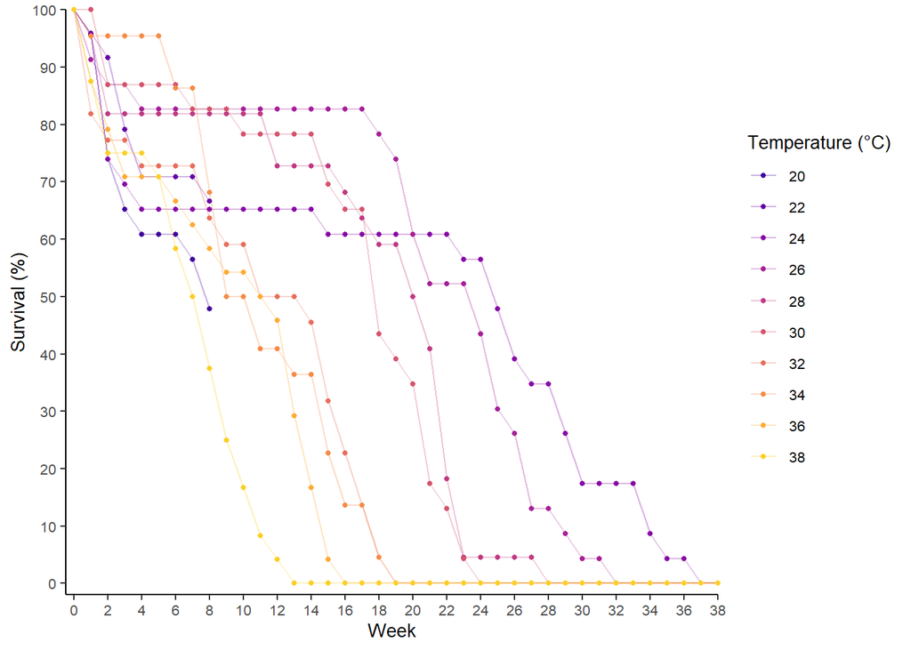

Figure 1: Proportion of crickets surviving each week. Crickets that were excluded from analysis or were culled were not included.

```r
surv_data <- tpc_survival %>%
  # Calculate week cricket died
  mutate(week_death = difftime(date_end, date_start, units = "week") %>%
           ceiling()) %>%
  # Remove excluded crickets
  filter(excluded == 0) %>%
  mutate(week = factor(week_death, levels = seq(0, 38)),
         temperature = as.factor(temperature)) %>%
  group_by(temperature, .drop = FALSE) %>%
  count(temperature, week) %>%
  mutate(deaths = cumsum(n),
         survival = ifelse(temperature %in% c(20, 22) & !week %in% seq(1,8),
                           NA,  1-(deaths / max(deaths))),
         week = as.numeric(week)-1) %>%
  mutate(survival = ifelse(week == 0 & is.na(survival), 1, survival))

surv_plot <- ggplot(surv_data, aes(week, survival * 100, group = temperature, colour = temperature)) +
  geom_line(alpha = 0.3) +
  geom_point(size = 1) +
  scale_colour_manual(name = "Temperature (°C)", values = temperature_pal) +
  scale_y_continuous(name = "Survival (%)",
                     expand = expansion(mult = c(0, 0),
                                        add = c(2, 0)),
                     labels = seq(100, 0, -10),
                     breaks = seq(100, 0, -10)) +
  scale_x_continuous(name = "Week",
                     breaks = seq(0, 38, 2),
                     expand = expansion(c(0, 0), c(0.5, 0))) +
  coord_cartesian(clip = "off")

surv_plot
```

## 3.1 Proportion surviving to adulthood

Cricket 183 is included in survival to adulthood, but not included in longevity (Was adult, accidental death).

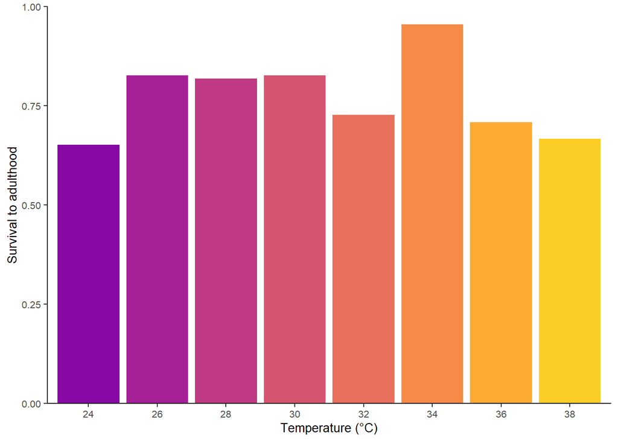

Figure 2: Proportion of crickets surviving to adulthood. Crickets that were excluded from analysis or were culled were not included.

```r
prop_adult <- tpc_survival %>%
  filter(excluded == 0,
         temperature >= 24) %>%
  group_by(temperature) %>%
  count(is.na(date_adult)) %>%
  pivot_wider(names_from = 2,
              values_from = 3) %>%
  rename("survived" = 2,
         "died" = 3) %>%
  mutate(total = survived + died,
         proportion = survived / total,
         temperature = factor(temperature))

prop_adult_plot <- ggplot(prop_adult, aes(temperature, proportion, fill = temperature)) +
  geom_col() +
  scale_fill_manual(values = temperature_pal[-c(1,2)]) +
  scale_x_discrete(name = "Temperature (°C)") +
  scale_y_continuous(name = "Survival to adulthood",
                     limits = c(0, 1),
                     expand = expansion(mult = c(0, 0))) +
  theme(legend.position = "none") +
  coord_cartesian(clip = "off")

prop_adult_plot
```

## 3.2 Statistics

Chi squared test comparing the frequencies of survival among temperature.

H0: Survival to adulthood is similar across temperatures. All temperature groups should have the same expected value, accounting for sample size.

Expected values:

```r
surv_adult <- tpc_survival %>%
  filter(excluded == 0,
         temperature >= 24) %>%
  group_by(temperature) %>%
  mutate(is.adult = ifelse(is.na(date_adult), "died", "adult"),
         temperature = as.factor(temperature)) %>%
  select(temperature, is.adult)

adult_test <- chisq.test(surv_adult$is.adult, surv_adult$temperature)
adult_test$expected # Check expected values
```

```
                   surv_adult$temperature
surv_adult$is.adult        24        26       28        30       32       34
              adult 17.721311 17.721311 16.95082 17.721311 16.95082 16.95082
              died   5.278689  5.278689  5.04918  5.278689  5.04918  5.04918
                   surv_adult$temperature
surv_adult$is.adult        36        38
              adult 18.491803 18.491803
              died   5.508197  5.508197
```

Chi-squared test statistic:

```r
adult_test
```

```
    Pearson's Chi-squared test

data:  surv_adult$is.adult and surv_adult$temperature
X-squared = 9.342, df = 7, p-value = 0.229
```

# 4 Crickets at low temperature

Summary statistics for crickets at 20 and 22 °C at 8 weeks when they were culled.

```r
tpc %>%
  filter(temperature <= 22,
         week == 8) %>%
  group_by(temperature) %>%
  summarise(mean_mass = mean(mass),
            se_mass = sd(mass)/ sqrt(n()),
            median_instar = median(instar),
            min_instar = min(instar),
            max_instar = max(instar)) %>%
  kable()
```

Table 4: Mass (mg) and instar of crickets reared at 20 and 22 °C after 8 weeks.

| temperature | mean_mass | se_mass | median_instar | min_instar | max_instar |
| --- | --- | --- | --- | --- | --- |
| 20 | 8.67 | 1.542087 | 4 | 2 | 5 |
| 22 | 12.04 | 1.619296 | 4 | 3 | 5 |

# 5 Growth curves

## 5.1 By week

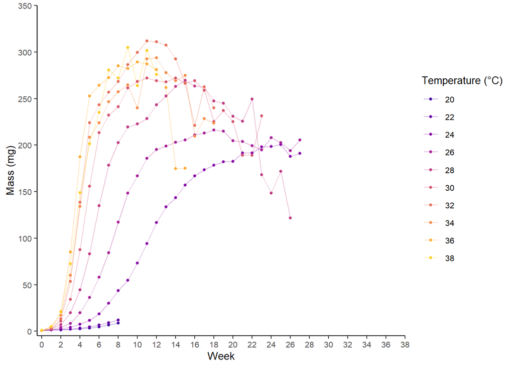

Figure 3: Mean mass (mg) of crickets reared at 10 temperatures (colours) each week. Variation around the mean is omitted.

```r
growth_curve <- tpc %>%
  group_by(temperature, week) %>%
  drop_na(mass) %>%
  summarise(mean = mean(mass),
            se = sd(mass)/sqrt(n())) %>%
  mutate(temperature = as.character(temperature)) %>%
  ggplot(aes(week, mean, col = temperature, group = temperature)) +
  geom_line(alpha = 0.3) +
  geom_point(size = 1) +
  scale_x_continuous(name = "Week",
                     limits = c(0, 38),
                     breaks = seq(0, 38, 2),
                     expand = expansion(c(0, 0), c(0.5, 0))) +
  scale_y_continuous(name = "Mass (mg)",
                     limits = c(0, 350),
                     breaks = seq(0, 450, 50),
                     expand = expansion(add = c(5, 0))) +
  scale_colour_manual(name = "Temperature (°C)", values = temperature_pal) +
  coord_cartesian(clip = "off")

growth_curve
```

## 5.2 Summary statistics

```r
# Mean of initial mass
tpc %>%
  filter(week == 0) %>%
  summarise(mean = mean(mass),
            se = sd(mass)/sqrt(n())) %>%
  round(., 3) %>%
  kable()
```

Table 5: Mean mass (mg) of first instar crickets at the start of the experiment.

| mean | se |
| --- | --- |
| 0.733 | 0.008 |

```r
# Mean adult mass
tpc %>%
  drop_na(adult_mass) %>%
  summarise(mean = mean(adult_mass),
            se = sd(adult_mass)/sqrt(n())) %>%
  round(., 3) %>%
  kable()
```

Table 6: Mean mass (mg) of adult crickets.

| mean | se |
| --- | --- |
| 217.902 | 1.372 |

```r
# Mean adult mass by sex
tpc %>%
  drop_na(adult_mass) %>%
  group_by(sex) %>%
  summarise(mean = mean(adult_mass),
            se = sd(adult_mass)/sqrt(n())) %>%
  kable()
```

Table 7: Mean adult mass (mg) of each sex.

| sex | mean | se |
| --- | --- | --- |
| Female | 258.8728 | 1.553637 |
| Male | 170.0351 | 1.297527 |

## 5.3 By instar

```r
# Label instances of adulthood
adult_index <- tpc %>% group_by(cricket) %>%
  filter(instar == 8) %>%
  mutate(index = row_number()) %>%
  select(observation, index)

juv <- tpc %>%
  filter(temperature %in% c(20, 22)) %>%
  group_by(temperature, instar) %>%
   summarise(mean_mass = mean(mass, na.rm = TRUE),
            se = sd(mass, na.rm = TRUE)/sqrt(n())) %>%
  mutate(temperature = factor(temperature))

# Add to original dataset and filter
tpc_instar <- left_join(tpc, adult_index, by = c("observation", "cricket")) %>%
  mutate(index = ifelse(is.na(index), 0, index),
         temperature = as.character(temperature)) %>%
  group_by(cricket) %>%
  filter(index <= 4,
         sex != "Juvenile") %>%
  # Calculate mean mass per instar for each individual
  group_by(cricket, temperature, instar, sex) %>%
  summarise(instar_mass = mean(mass, na.rm = TRUE)) %>%
  ungroup() %>%
  # Calculate mean mass per instar, pooling individuals
  group_by(temperature, instar, sex) %>%
  summarise(mean_mass = mean(instar_mass, na.rm = TRUE),
            se = sd(instar_mass, na.rm = TRUE)/sqrt(n())) %>%
  ungroup() %>%
  bind_rows(mutate(juv, sex = "Female"),
            mutate(juv, sex = "Male"),
            .)
```

```r
instarmassmod <- left_join(tpc, adult_index, by = c("observation", "cricket")) %>%
  mutate(index = ifelse(is.na(index), 0, index),
         temperature = as.character(temperature),
         instar = as.character(instar)) %>%
  group_by(cricket) %>%
  filter(index <= 4,
         sex != "Juvenile") %>%
  # Calculate mean mass per instar for each individual
  group_by(cricket, temperature, instar, sex) %>%
  summarise(instar_mass = mean(mass, na.rm = TRUE)) %>%
  ungroup() %>%
  lm(instar_mass ~ instar + temperature + sex + instar:temperature, .)

instarmassmod %>%
  anova() %>%
  kable()
```

Table 8: ANOVA table testing for an interaction between instar and temperature on mass.

|  | Df | Sum Sq | Mean Sq | F value | Pr(>F) |
| --- | --- | --- | --- | --- | --- |
| instar | 7 | 6151751.66 | 878821.6660 | 1143.357338 | 0 |
| temperature | 7 | 84450.85 | 12064.4075 | 15.695936 | 0 |
| sex | 1 | 71049.55 | 71049.5545 | 92.436307 | 0 |
| instar:temperature | 46 | 122203.27 | 2656.5929 | 3.456259 | 0 |
| Residuals | 842 | 647188.61 | 768.6325 | NA | NA |

Post-hoc test suggests that mass is similar across temperatures for early instars and only starts to differ at instars 7 and 8.

```r
emmeans(instarmassmod, pairwise ~ temperature | instar) %>%
  pairs(adjust = "tukey") %>%
  tidy() %>%
  filter(adj.p.value < 0.05) %>%
  kable()
```

Table 9: Post-hoc analysis testing for an interaction between instar and temperature on mass. Non-significant pairs are omitted.

| instar | term | contrast | null.value | estimate | std.error | df | statistic | adj.p.value |
| --- | --- | --- | --- | --- | --- | --- | --- | --- |
| 7 | temperature | temperature24 - temperature30 | 0 | -36.23348 | 9.713868 | 842 | -3.730077 | 0.0050153 |
| 7 | temperature | temperature24 - temperature32 | 0 | -50.25390 | 9.973865 | 842 | -5.038559 | 0.0000158 |
| 7 | temperature | temperature24 - temperature34 | 0 | -36.77209 | 9.694850 | 842 | -3.792950 | 0.0039591 |
| 7 | temperature | temperature24 - temperature36 | 0 | -37.81167 | 11.689559 | 842 | -3.234653 | 0.0276126 |
| 7 | temperature | temperature26 - temperature30 | 0 | -33.00940 | 9.123035 | 842 | -3.618248 | 0.0075553 |
| 7 | temperature | temperature26 - temperature32 | 0 | -47.02983 | 9.407379 | 842 | -4.999249 | 0.0000192 |
| 7 | temperature | temperature26 - temperature34 | 0 | -33.54801 | 9.120373 | 842 | -3.678359 | 0.0060723 |
| 7 | temperature | temperature26 - temperature36 | 0 | -34.58759 | 11.224845 | 842 | -3.081342 | 0.0441057 |
| 7 | temperature | temperature32 - temperature38 | 0 | 32.56416 | 10.150269 | 842 | 3.208207 | 0.0299983 |
| 8 | temperature | temperature24 - temperature28 | 0 | -46.31809 | 9.713868 | 842 | -4.768244 | 0.0000596 |
| 8 | temperature | temperature24 - temperature30 | 0 | -73.94270 | 9.599825 | 842 | -7.702506 | 0.0000000 |
| 8 | temperature | temperature24 - temperature32 | 0 | -91.86518 | 9.973865 | 842 | -9.210590 | 0.0000000 |
| 8 | temperature | temperature24 - temperature34 | 0 | -68.60441 | 9.374306 | 842 | -7.318346 | 0.0000000 |
| 8 | temperature | temperature24 - temperature36 | 0 | -95.70950 | 9.828506 | 842 | -9.737950 | 0.0000000 |
| 8 | temperature | temperature24 - temperature38 | 0 | -80.97948 | 9.996527 | 842 | -8.100762 | 0.0000000 |
| 8 | temperature | temperature26 - temperature30 | 0 | -49.94033 | 9.000103 | 842 | -5.548862 | 0.0000011 |
| 8 | temperature | temperature26 - temperature32 | 0 | -67.86281 | 9.407379 | 842 | -7.213785 | 0.0000000 |
| 8 | temperature | temperature26 - temperature34 | 0 | -44.60204 | 8.780182 | 842 | -5.079854 | 0.0000128 |
| 8 | temperature | temperature26 - temperature36 | 0 | -71.70713 | 9.255704 | 842 | -7.747345 | 0.0000000 |
| 8 | temperature | temperature26 - temperature38 | 0 | -56.97711 | 9.417052 | 842 | -6.050419 | 0.0000001 |
| 8 | temperature | temperature28 - temperature32 | 0 | -45.54709 | 9.527953 | 842 | -4.780365 | 0.0000562 |
| 8 | temperature | temperature28 - temperature36 | 0 | -49.39141 | 9.380080 | 842 | -5.265564 | 0.0000049 |
| 8 | temperature | temperature28 - temperature38 | 0 | -34.66139 | 9.527187 | 842 | -3.638156 | 0.0070311 |

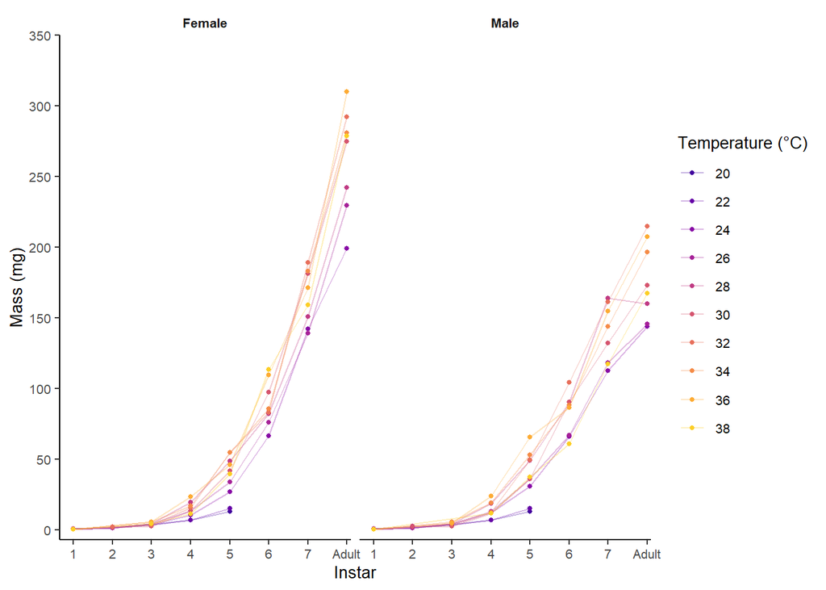

Figure 4: Mean mass (mg) for each instar of crickets reared under one of 10 temperatures (colours). The mean mass at each instar for each individual was used to calculate mean instar mass pooling individuals. The first four observations of mass for each cricket were used to calculate mass at adulthood. Variation around the mean is omitted.

```r
instar_curve <- ggplot(tpc_instar, aes(instar, mean_mass, col = temperature, group = temperature)) +
  geom_line(alpha = 0.3) +
  geom_point(size = 1) +
  scale_colour_manual(name = "Temperature (°C)", values = temperature_pal) +
  scale_y_continuous(name = "Mass (mg)",
                     expand = expansion(mult = c(0.02,0)),
                     limits = c(0, 350),
                     breaks = seq(0, 400, by = 50)) +
  scale_x_continuous(name = "Instar",
                     expand = expansion(mult = c(0.05,0)),
                     limits = c(1, 8.1),
                     breaks = seq(1, 8, by = 1),
                     labels = c(1:7, "Adult")) +
  facet_grid(~sex) +
  coord_cartesian(clip = "off")

instar_curve
```

# 6 Adults mass

Get mean of the first four observations of adult mass (1 month of adulthood).

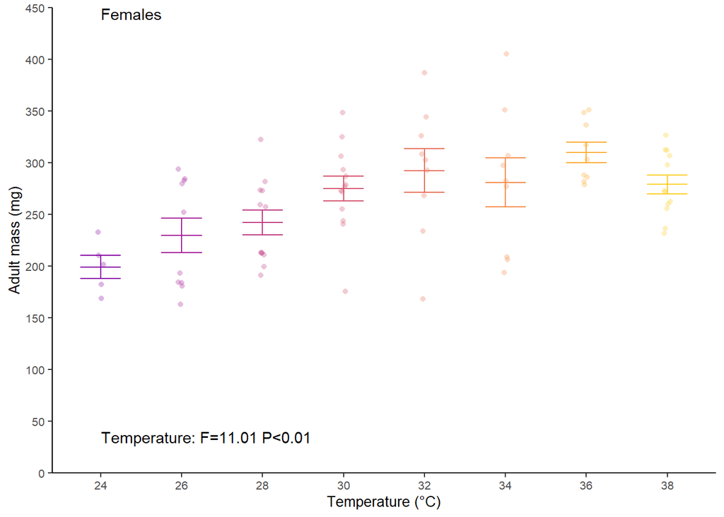

Figure 5: Mean mass (± standard error) of adult female crickets reared at 8 temperatures (colours).

```r
female_mass <- tpc %>%
  filter(temperature >= 24,
         sex == "Female",
         !is.na(adult_mass)) %>%
  mutate(temperature = as.character(temperature)) %>%
  select(cricket, temperature, sex, adult_mass) %>%
  distinct() %>%
  ggplot(aes(temperature, adult_mass, colour = temperature)) +
    stat_summary(fun.data = mean_se, geom = "errorbar", width = 0.5) +
  stat_summary(geom = "crossbar",
               fun = mean,
               width = 0.5,
               fatten = 1) +
  geom_point(aes(shape = sex),
             alpha = 0.3,
             position = position_jitterdodge(
    jitter.height = 0,
    jitter.width = 0.2,
    dodge.width = 1),
    size = 1.5) +
  scale_colour_manual(name = "Temperature (°C)", values = temperature_pal[-c(1,2)]) +
  scale_y_continuous(name = "Adult mass (mg)",
                     breaks = seq(0, 450, 50),
                     expand = expansion(mult = c(0, 0)),
                     limits = c(0, 450)) +
  labs(x =  "Temperature (°C)") +
  scale_shape_manual(name = "Sex",
                     values = c(16, 1)) +
  theme(legend.position = "none") +
  coord_cartesian(clip = "off") +
  annotate("text", label = "Females", x = 1, y = Inf, vjust = 1, hjust = 0) +
  annotate("text", label = "Temperature: F=11.01 P<0.01", x = 1, y = 450/11, vjust = 1, hjust = 0)

female_mass
```

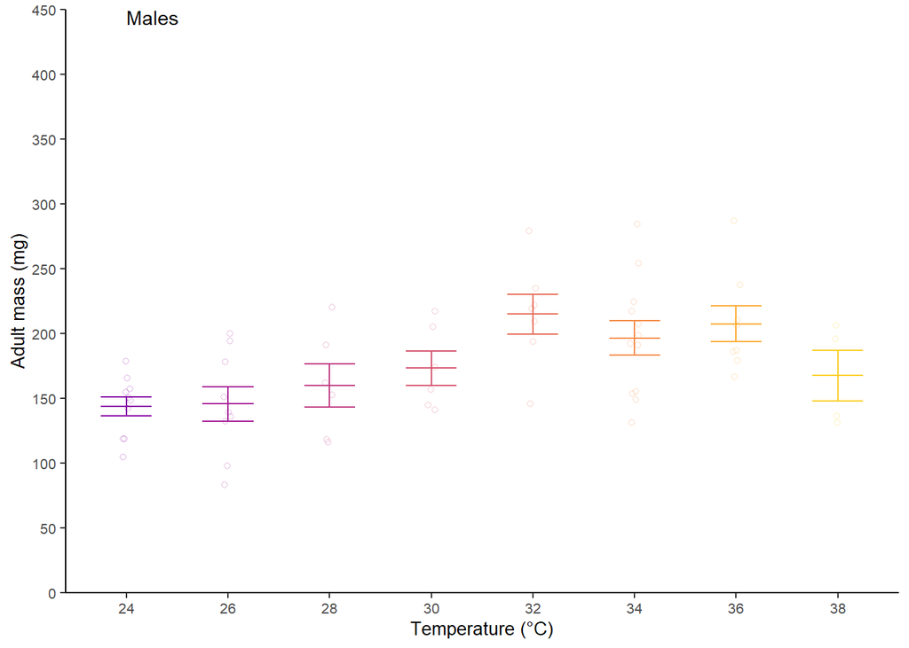

Figure 6: Mean mass (± standard error) of adult male crickets reared at 8 temperatures (colours).

```r
male_mass <- tpc %>%
  filter(temperature >= 24,
         sex == "Male",
         !is.na(adult_mass)) %>%
  mutate(temperature = as.character(temperature)) %>%
  select(cricket, temperature, sex, adult_mass) %>%
  distinct() %>%
  ggplot(aes(temperature, adult_mass, colour = temperature)) +
    stat_summary(fun.data = mean_se, geom = "errorbar", width = 0.5) +
  stat_summary(geom = "crossbar",
               fun = mean,
               width = 0.5,
               fatten = 1) +
  geom_point(aes(shape = sex),
             alpha = 0.3,
             position = position_jitterdodge(
    jitter.height = 0,
    jitter.width = 0.2,
    dodge.width = 1),
    size = 1.5) +
  scale_colour_manual(name = "Temperature (°C)", values = temperature_pal[-c(1,2)]) +
  scale_y_continuous(name = "Adult mass (mg)",
                     breaks = seq(0, 450, 50),
                     expand = expansion(mult = c(0, 0)),
                     limits = c(0, 450)) +
  labs(x =  "Temperature (°C)") +
  scale_shape_manual(name = "Sex",
                     values = c(1, 16)) +
  theme(legend.position = "none") +
  coord_cartesian(clip = "off") +
  annotate("text", label = "Males", x = 1, y = Inf, vjust = 1, hjust = 0)

male_mass
```

### 6.0.1 ANOVA

1. Test a dependency of sex

There is no interaction between sex and temperature.

```r
mass_mod <- lm(adult_mass ~ temperature * sex, tpc %>%
  filter(temperature >= 24,
         sex != "Juvenile",
         !is.na(adult_mass)) %>%
     mutate(temperature = factor(temperature,
                              levels = c("32", "24","26","28","30","34","36","38"))) %>%
  select(cricket, temperature, sex, adult_mass) %>%
  distinct())

anova(mass_mod) %>% kable()
```

Table 10: ANOVA testing the effect of temperature and sex on adult mass.

|  | Df | Sum Sq | Mean Sq | F value | Pr(>F) |
| --- | --- | --- | --- | --- | --- |
| temperature | 7 | 142474.382 | 20353.483 | 10.7570798 | 0.0000000 |
| sex | 1 | 247571.222 | 247571.222 | 130.8446012 | 0.0000000 |
| temperature:sex | 7 | 7591.091 | 1084.442 | 0.5731414 | 0.7766326 |
| Residuals | 125 | 236512.645 | 1892.101 | NA | NA |

2. Update the model to an additive model

Both sex and temperature are significant. Performed a Tukey correction on estimated marginal means as a post-hoc test. Averaged over sex because the model is additive.

```r
# Update model to remove interaction
mass_mod <- update(mass_mod, . ~ . -temperature:sex)
anova(mass_mod) %>% kable()
```

Table 11: Reduced ANOVA testing the independent effects of temperature and sex on adult mass.

|  | Df | Sum Sq | Mean Sq | F value | Pr(>F) |
| --- | --- | --- | --- | --- | --- |
| temperature | 7 | 142474.4 | 20353.483 | 11.00622 | 0 |
| sex | 1 | 247571.2 | 247571.222 | 133.87506 | 0 |
| Residuals | 132 | 244103.7 | 1849.271 | NA | NA |

Model assumptions:

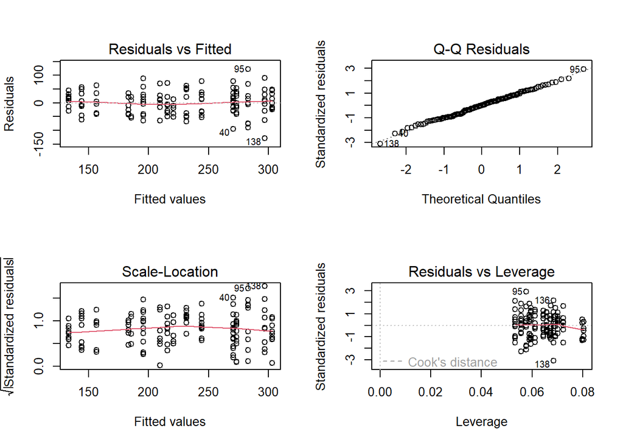

```r
# Check model assumptions - all good
par(mfrow = c(2,2))
plot(mass_mod)
```

```r
par(mfrow = c(1,1))
```

```r
# Estimated marginal means with Tukey correction
emmeans(mass_mod, ~temperature) %>% pairs(adjust = "tukey") %>%
  tidy() %>%
  filter(adj.p.value < 0.05) %>%
  kable()
```

Table 12: Tukey’s Honest Significant Differences for the reduced ANOVA. Non-significant contrast pairs are omitted.

| term | contrast | null.value | estimate | std.error | df | statistic | adj.p.value |
| --- | --- | --- | --- | --- | --- | --- | --- |
| temperature | temperature32 - temperature24 | 0 | 76.11869 | 15.55163 | 132 | 4.894579 | 0.0000757 |
| temperature | temperature32 - temperature26 | 0 | 65.37652 | 14.59397 | 132 | 4.479694 | 0.0004178 |
| temperature | temperature32 - temperature28 | 0 | 52.70459 | 14.79643 | 132 | 3.561981 | 0.0117076 |
| temperature | temperature24 - temperature30 | 0 | -49.83324 | 15.08715 | 132 | -3.303026 | 0.0262956 |
| temperature | temperature24 - temperature34 | 0 | -62.06042 | 14.55546 | 132 | -4.263720 | 0.0009710 |
| temperature | temperature24 - temperature36 | 0 | -82.23657 | 15.30535 | 132 | -5.373062 | 0.0000093 |
| temperature | temperature24 - temperature38 | 0 | -52.34950 | 15.77167 | 132 | -3.319212 | 0.0250467 |
| temperature | temperature26 - temperature34 | 0 | -51.31825 | 13.63577 | 132 | -3.763501 | 0.0059742 |
| temperature | temperature26 - temperature36 | 0 | -71.49440 | 14.35657 | 132 | -4.979907 | 0.0000526 |
| temperature | temperature28 - temperature36 | 0 | -58.82246 | 14.58047 | 132 | -4.034332 | 0.0022897 |

### 6.0.2 Coefficient of variation

```r
tpc %>%
  filter(temperature >= 24,
         !is.na(adult_mass)) %>%
  mutate(temperature = as.character(temperature)) %>%
  select(cricket, temperature, sex, adult_mass) %>%
  distinct() %>%
  group_by(temperature, sex) %>%
  summarise(CV = (sd(adult_mass) / mean(adult_mass)) * 100) %>%
  arrange(sex, CV) %>%
  kable()
```

Table 13: Coefficient of variation for temperatures and sexes.

| temperature | sex | CV |
| --- | --- | --- |
| 36 | Female | 9.438348 |
| 38 | Female | 11.258493 |
| 24 | Female | 12.461935 |
| 30 | Female | 15.474193 |
| 28 | Female | 16.926725 |
| 32 | Female | 21.801054 |
| 26 | Female | 23.049113 |
| 34 | Female | 25.056436 |
| 24 | Male | 16.103153 |
| 30 | Male | 18.432280 |
| 36 | Male | 18.713766 |
| 32 | Male | 18.842273 |
| 34 | Male | 22.997573 |
| 38 | Male | 23.301002 |
| 28 | Male | 25.372960 |
| 26 | Male | 27.468331 |

# 7 Development time

Time to adulthood (eighth instar) varies among temperatures with lower temperatures developing slower (Figure 7). Different even at the higher temperatures.

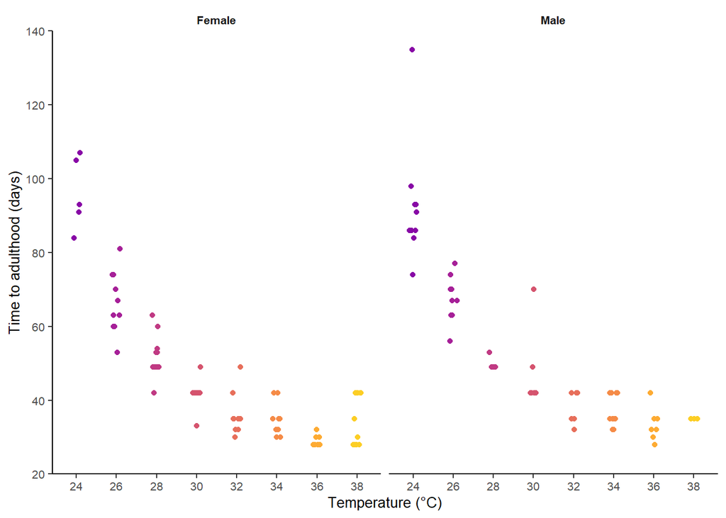

Figure 7: Development time to eighth instar (fully developed ovipositor and wings) for male and female crickets (points) reared at 8 temperatures (colours).

```r
tpc %>%
  filter(sex != "Juvenile",
         !is.na(time_maturity)) %>%
  select(temperature, cricket, sex, time_maturity) %>%
  distinct() %>%
  mutate(temperature = as.character(temperature)) %>%
  ggplot(aes(temperature, time_maturity, colour = temperature)) +
  geom_jitter(width = 0.1, height = 0) +
  scale_colour_manual(values = temperature_pal[-c(1,2)]) +
  scale_y_continuous(limits = c(20, 140),
                     breaks = seq(0, 140, 20),
                     expand = expansion(mult = c(0,0)))+
  labs(x = "Temperature (°C)",
       y = "Time to adulthood (days)") +
  theme(legend.position = "none") +
  facet_grid(.~sex)
```

## 7.1 Summary stats

### 7.1.1 By temperature

```r
tpc %>%
  filter(temperature >= 24) %>%
  drop_na(time_maturity) %>%
  # Group data by temperature
  group_by(temperature) %>%
  summarise(mean = mean(time_maturity),
            se = sd(time_maturity)/sqrt(n())) %>%
  kable(digits = 1,
        col.names = c("Rearing temperature (°C)",
                      "Mean time (days)",
                      "Standard error"))
```

Table 14: Development time (days) to reach maturity from the start of the experiment (Week 0) for each temperature.

| Rearing temperature (°C) | Mean time (days) | Standard error |
| --- | --- | --- |
| 24 | 94.1 | 0.7 |
| 26 | 66.8 | 0.3 |
| 28 | 51.1 | 0.2 |
| 30 | 43.8 | 0.4 |
| 32 | 37.3 | 0.3 |
| 34 | 36.4 | 0.3 |
| 36 | 31.5 | 0.3 |
| 38 | 35.2 | 0.5 |

### 7.1.2 By sex

```r
tpc %>%
  filter(temperature >= 24) %>%
  drop_na(time_maturity) %>%
  # Group data by temperature
  group_by(sex) %>%
  summarise(mean = mean(time_maturity),
            se = sd(time_maturity)/sqrt(n())) %>%
  kable(digits = 1,
        col.names = c("Sex",
                      "Mean time (days)",
                      "Standard error"))
```

Table 15: Development time (days) to reach maturity from the start of the experiment (Week 0) for each sex.

| Sex | Mean time (days) | Standard error |
| --- | --- | --- |
| Female | 51.0 | 0.6 |
| Male | 58.7 | 0.7 |

# 8 Development rate

```r
female_dev <- tpc %>%
  filter(!is.na(dev_rate),
         sex == "Female") %>%
  select(temperature, cricket, sex, dev_rate) %>%
  distinct() %>%
  mutate(temperature = as.character(temperature)) %>%
  ggplot(aes(temperature, dev_rate, colour = temperature)) +
  geom_hline(yintercept = 1/42, linetype = 2, colour = "grey") +
    stat_summary(fun.data = mean_se, geom = "errorbar", width = 0.5) +
  stat_summary(geom = "crossbar",
               fun = mean,
               width = 0.5,
               fatten = 1) +
  geom_point(aes(shape = sex),
             alpha = 0.3,
             position = position_jitterdodge(
    jitter.height = 0,
    jitter.width = 0.7,
    dodge.width = 1),
    size = 1.5) +
  scale_colour_manual(values = temperature_pal[-c(1,2)]) +
  scale_y_continuous(limits = c(0, 0.045),
                     expand = expansion(mult = c(0, 0)),
                     breaks = seq(0, 0.05, 0.005)) +
  labs(x = "Temperature (°C)",
       y = expression(~Development~rate~(day^-1))) +
    scale_shape_manual(name = "Sex",
                      values = c(16)) +
  theme(legend.position = "none") +
  coord_cartesian(clip = "off") +
  annotate("text", label = "Females", x = 1, y = Inf, vjust = 1, hjust = 0) +
  annotate("text", label = "Temperature: F=105.5 P<0.01", x = 1, y = 0.045/11, vjust = 1, hjust = 0)
```

```r
male_dev <- tpc %>%
  filter(!is.na(dev_rate),
         sex == "Male") %>%
  select(temperature, cricket, sex, dev_rate) %>%
  distinct() %>%
  mutate(temperature = as.character(temperature)) %>%
  ggplot(aes(temperature, dev_rate, colour = temperature)) +
  geom_hline(yintercept = 1/42, linetype = 2, colour = "grey") +
    stat_summary(fun.data = mean_se, geom = "errorbar", width = 0.5) +
  stat_summary(geom = "crossbar",
               fun = mean,
               width = 0.5,
               fatten = 1) +
  geom_point(aes(shape = sex),
             alpha = 0.3,
             position = position_jitterdodge(
    jitter.height = 0,
    jitter.width = 0.7,
    dodge.width = 1),
    size = 1.5) +
  scale_colour_manual(values = temperature_pal[-c(1,2)]) +
  scale_y_continuous(limits = c(0, 0.045),
                     expand = expansion(mult = c(0, 0)),
                     breaks = seq(0, 0.05, 0.005)) +
  labs(x = "Temperature (°C)",
       y = expression(~Development~rate~(day^-1))) +
    scale_shape_manual(name = "Sex",
                      values = c(1)) +
  theme(legend.position = "none") +
  coord_cartesian(clip = "off") +
  annotate("text", label = "Males", x = 1, y = Inf, vjust = 1, hjust = 0)
```

### 8.0.1 ANOVA of development rate

1. Test a dependency of sex

There is no interaction between sex and temperature.

```r
devrate_mod <- lm(dev_rate ~ temperature * sex, tpc %>%
  filter(temperature >= 24,
         sex != "Juvenile",
         !is.na(dev_rate)) %>%
     mutate(temperature = factor(temperature,
                              levels = c("32", "24","26","28","30","34","36","38"))) %>%
  select(cricket, temperature, sex, dev_rate) %>%
  distinct())

anova(devrate_mod) %>% kable()
```

Table 16: ANOVA testing the effect of temperature and sex on development rate to adulthood.

|  | Df | Sum Sq | Mean Sq | F value | Pr(>F) |
| --- | --- | --- | --- | --- | --- |
| temperature | 7 | 0.0066769 | 0.0009538 | 106.661303 | 0.0000000 |
| sex | 1 | 0.0000715 | 0.0000715 | 7.999821 | 0.0054508 |
| temperature:sex | 7 | 0.0000754 | 0.0000108 | 1.204843 | 0.3049798 |
| Residuals | 125 | 0.0011178 | 0.0000089 | NA | NA |

2. Update the model to an additive model

Both sex and temperature are significant. Post hoc test indicates 38 °C is similar to 32 and 34 °C.

```r
devrate_mod <- update(devrate_mod, . ~ . -temperature:sex)
anova(devrate_mod) %>% kable()
```

|  | Df | Sum Sq | Mean Sq | F value | Pr(>F) |
| --- | --- | --- | --- | --- | --- |
| temperature | 7 | 0.0066769 | 0.0009538 | 105.515101 | 0.0000000 |
| sex | 1 | 0.0000715 | 0.0000715 | 7.913854 | 0.0056559 |
| Residuals | 132 | 0.0011933 | 0.0000090 | NA | NA |

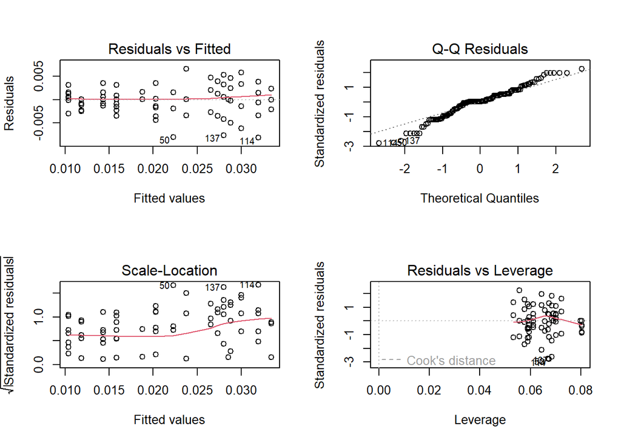

```r
# Check model assumptions - good enough
par(mfrow = c(2,2))
plot(devrate_mod)
```

```r
par(mfrow = c(1,1))
```

```r
# Estimated marginal means with Tukey correction
emmeans(devrate_mod, ~temperature) %>% pairs(adjust = "tukey") %>%
  tidy() %>%
  filter(adj.p.value > 0.05) %>%
  kable()
```

Table 18: Tukey’s Honest Significant Differences for the reduced ANOVA. Significant contrast pairs are omitted.

| term | contrast | null.value | estimate | std.error | df | statistic | adj.p.value |
| --- | --- | --- | --- | --- | --- | --- | --- |
| temperature | temperature32 - temperature34 | 0 | -0.0007736 | 0.0010002 | 132 | -0.7734221 | 0.9941909 |
| temperature | temperature32 - temperature38 | 0 | -0.0019619 | 0.0010676 | 132 | -1.8376699 | 0.5957670 |
| temperature | temperature34 - temperature38 | 0 | -0.0011883 | 0.0010120 | 132 | -1.1741687 | 0.9378842 |

# 9 Longevity

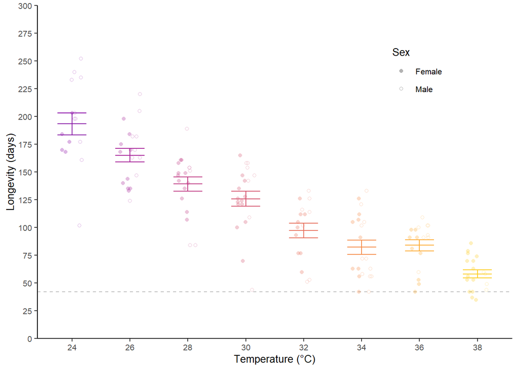

```r
lifespan_graph <- tpc %>%
  filter(sex != "Juvenile",
         reason_removed == "Dead",
         temperature >= 24) %>%
  select(temperature, cricket, sex, longevity) %>%
  distinct() %>%
  mutate(temperature = as.character(temperature)) %>%
  ggplot(aes(temperature, longevity, colour = temperature)) +
  geom_hline(yintercept = 42, linetype = 2, colour = "grey") +
      stat_summary(fun.data = mean_se, geom = "errorbar", width = 0.5,
               show.legend = FALSE) +
  stat_summary(geom = "crossbar",
               fun = mean,
               width = 0.5,
               show.legend = FALSE,
               fatten = 1) +
  geom_point(aes(shape = sex),
             alpha = 0.3,
             position = position_jitterdodge(
    jitter.height = 0,
    jitter.width = 0.5,
    dodge.width = 0.3),
    size = 1.5) +
  xlab("Temperature (°C)") +
  scale_y_continuous(name = "Longevity (days)",
                     limits = c(0, 300),
                     expand = expansion(mult = c(0, 0)),
                     breaks = seq(0, 300, 25)) +
  scale_colour_manual(values = temperature_pal[3:10], guide = "none") +
  scale_shape_manual(name = "Sex",
                      values = c(16, 1)) +
  theme(legend.position = "inside",
        legend.position.inside = c(0.8, 0.8)) +
  coord_cartesian(clip = "off")

lifespan_graph
```

## 9.1 ANOVA

1. Test a dependency of sex

There is no interaction between sex and temperature.

```r
lifespan_mod <- lm(longevity ~ temperature * sex, tpc %>%
  filter(temperature >= 24,
         sex != "Juvenile",
         !is.na(longevity)) %>%
     mutate(temperature = factor(temperature,
                              levels = c("32", "24","26","28","30","34","36","38"))) %>%
  select(cricket, temperature, sex, longevity) %>%
  distinct())

anova(lifespan_mod) %>% kable()
```

Table 19: ANOVA testing the effect of temperature and sex on longevity.

|  | Df | Sum Sq | Mean Sq | F value | Pr(>F) |
| --- | --- | --- | --- | --- | --- |
| temperature | 7 | 256504.5710 | 36643.5101 | 48.5493794 | 0.0000000 |
| sex | 1 | 943.4981 | 943.4981 | 1.2500507 | 0.2656368 |
| temperature:sex | 7 | 3474.2657 | 496.3237 | 0.6575846 | 0.7074566 |
| Residuals | 128 | 96610.2833 | 754.7678 | NA | NA |

2. Update the model to an additive model

Temperature is significant.  
Sex is not significant.

```r
lifespan_mod <- update(lifespan_mod, . ~ . -temperature:sex)
anova(lifespan_mod) %>% kable()
```

Table 20: Reduced ANOVA testing the independent effects of temperature and sex on longevity.

|  | Df | Sum Sq | Mean Sq | F value | Pr(>F) |
| --- | --- | --- | --- | --- | --- |
| temperature | 7 | 256504.5710 | 36643.5101 | 49.426949 | 0.0000000 |
| sex | 1 | 943.4981 | 943.4981 | 1.272646 | 0.2612717 |
| Residuals | 135 | 100084.5490 | 741.3670 | NA | NA |

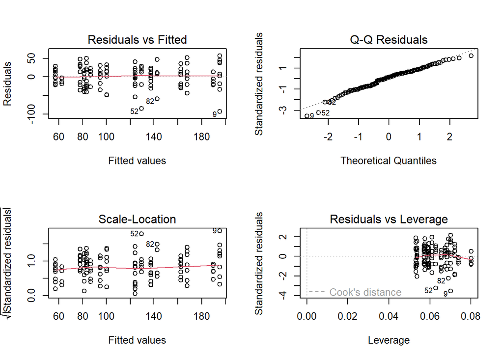

```r
# Check model assumptions - all good
par(mfrow = c(2,2))
plot(lifespan_mod)
```

```r
par(mfrow = c(1,1))
```

```r
# Estimated marginal means with Tukey correction
emmeans(lifespan_mod, ~temperature) %>% pairs(adjust = "tukey") %>%
  tidy() %>%
  filter(adj.p.value > 0.05) %>%
  kable()
```

Table 21: Tukey’s Honest Significant Differences for the reduced ANOVA. Significant contrast pairs are omitted.

| term | contrast | null.value | estimate | std.error | df | statistic | adj.p.value |
| --- | --- | --- | --- | --- | --- | --- | --- |
| temperature | temperature32 - temperature34 | 0 | 17.170970 | 9.057650 | 135 | 1.8957423 | 0.5562536 |
| temperature | temperature32 - temperature36 | 0 | 13.489299 | 9.485243 | 135 | 1.4221353 | 0.8455374 |
| temperature | temperature24 - temperature26 | 0 | 27.225134 | 9.448771 | 135 | 2.8813414 | 0.0845773 |
| temperature | temperature26 - temperature28 | 0 | 25.260914 | 8.980439 | 135 | 2.8128819 | 0.1004064 |
| temperature | temperature28 - temperature30 | 0 | 13.308036 | 8.846561 | 135 | 1.5043174 | 0.8039296 |
| temperature | temperature34 - temperature36 | 0 | -3.681672 | 8.896131 | 135 | -0.4138509 | 0.9998999 |
| temperature | temperature34 - temperature38 | 0 | 20.769026 | 8.900895 | 135 | 2.3333638 | 0.2835464 |
| temperature | temperature36 - temperature38 | 0 | 24.450698 | 9.283357 | 135 | 2.6338206 | 0.1531232 |

```r
tpc %>%
  filter(sex != "Juvenile",
         reason_removed == "Dead",
         temperature >= 24) %>%
  select(temperature, cricket, sex, longevity) %>%
  distinct() %>%
  group_by(sex, temperature) %>%
  summarise(min = min(longevity),
            max = max(longevity),
            n = n()) %>%
  kable(col.names = c("Sex",
                      "Rearing temperature (°C)",
                      "Min lifespan (days)",
                      "Max lifespan (days)",
                      "Sample size"))
```

Table 22: Lifespan ranges and sample size for each sex and rearing temperature.

| Sex | Rearing temperature (°C) | Min lifespan (days) | Max lifespan (days) | Sample size |
| --- | --- | --- | --- | --- |
| Female | 24 | 168.0417 | 203.0417 | 5 |
| Female | 26 | 133.0000 | 198.0417 | 10 |
| Female | 28 | 107.0000 | 161.0000 | 12 |
| Female | 30 | 70.0000 | 165.0000 | 13 |
| Female | 32 | 60.0000 | 126.0000 | 9 |
| Female | 34 | 42.0000 | 126.0000 | 9 |
| Female | 36 | 42.0000 | 98.0000 | 9 |
| Female | 38 | 35.0000 | 86.0000 | 14 |
| Male | 24 | 102.0000 | 252.0417 | 10 |
| Male | 26 | 124.0000 | 220.0417 | 9 |
| Male | 28 | 84.0000 | 189.0417 | 6 |
| Male | 30 | 44.0000 | 158.0000 | 7 |
| Male | 32 | 51.0000 | 133.0000 | 7 |
| Male | 34 | 42.0000 | 133.0000 | 11 |
| Male | 36 | 60.0000 | 109.0000 | 8 |
| Male | 38 | 44.0000 | 60.0000 | 4 |

## 9.2 Adult lifespan

Compare with Archer et al. 2013. Calculated from the time of adulthood to death.

```r
tpc %>%
  filter(temperature >= 24,
         sex != "Juvenile") %>%
  group_by(temperature, sex) %>%
  mutate(adult_lifespan = longevity - time_maturity) %>%
  drop_na(adult_lifespan) %>%
  summarise(mean = mean(adult_lifespan),
            se = sd(adult_lifespan)/sqrt(n())) %>%
  kable(digits = 2)
```

Table 23: Adult lifespan (days) for each sex and rearing temperature.

| temperature | sex | mean | se |
| --- | --- | --- | --- |
| 24 | Female | 84.96 | 1.35 |
| 24 | Male | 112.17 | 2.26 |
| 26 | Female | 94.83 | 1.56 |
| 26 | Male | 108.74 | 1.84 |
| 28 | Female | 91.03 | 1.07 |
| 28 | Male | 97.24 | 3.17 |
| 30 | Female | 85.91 | 1.40 |
| 30 | Male | 99.02 | 1.81 |
| 32 | Female | 63.11 | 1.70 |
| 32 | Male | 69.95 | 2.64 |
| 34 | Female | 58.30 | 2.28 |
| 34 | Male | 50.79 | 2.70 |
| 36 | Female | 52.02 | 1.81 |
| 36 | Male | 61.75 | 1.03 |
| 38 | Female | 31.83 | 1.21 |
| 38 | Male | 18.53 | 1.16 |

# 10 Yield

Yield is calculated two ways:

## 10.1 1. Maximum potential yield at adulthood

Yield if a cricket is harvested as soon as they reach adulthood. In practice, crickets mature at different rates.

$$yield =
\frac{adult \ mass}{development \ time}$$

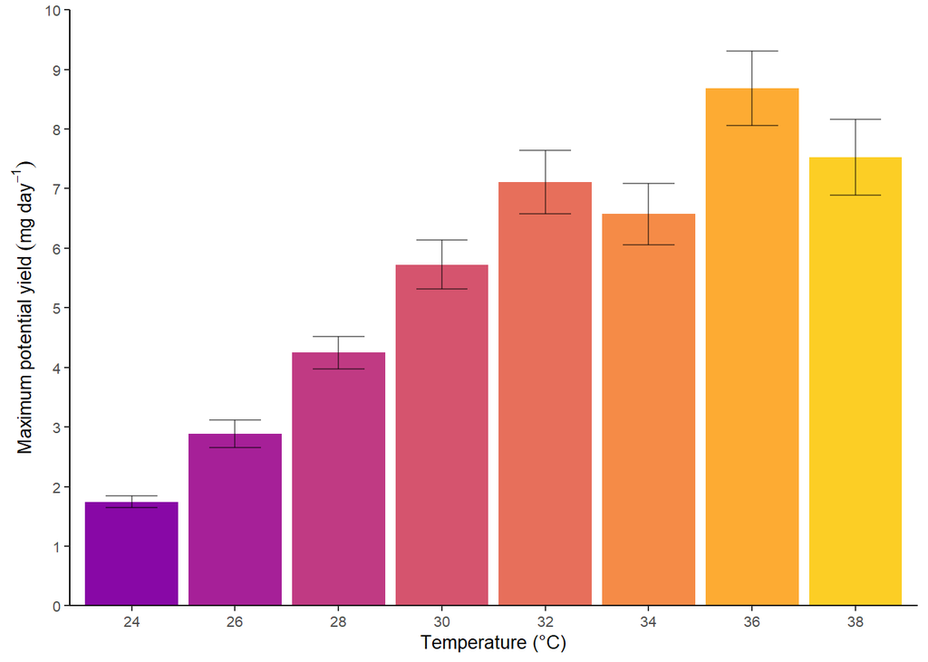

Figure 9: Maximum potential yield calculated for each individual based on when they reach adulthood.

```r
individual_yield <- tpc %>%
  filter(temperature >= 24) %>%
  mutate(temperature = as.factor(temperature)) %>%
  distinct(temperature, adult_mass, cricket, time_maturity) %>%
  mutate(yield_index = adult_mass / time_maturity) %>%
  group_by(temperature) %>%
  drop_na(yield_index)

individual_yield_plot <- individual_yield %>%
  summarise(temp_yield = mean(yield_index),
            yield_se = sd(yield_index)/sqrt(n())) %>%
  ggplot(aes(temperature, temp_yield,
             group = temperature,
             fill = temperature)) +
  geom_col() +
  geom_errorbar(aes(y = temp_yield,
                    ymin = temp_yield - yield_se,
                    ymax = temp_yield + yield_se),
                width = 0.5, alpha = 0.5) +
  scale_fill_manual(values = temperature_pal[-c(1,2)])  +
  scale_x_discrete(name = "Temperature (°C)") +
  scale_y_continuous(name = expression(Maximum~potential~yield~(mg~day^-1)),
                     limits = c(0, 10),
                     breaks = seq(0, 10, 1),
                     expand = c(0, 0)) +
  theme(legend.position = "none")

individual_yield_plot
```

```r
yield_mod <- lm(yield_index ~ temperature, individual_yield)
anova(yield_mod) %>% kable()
```

Table 24: ANOVA of the effect of temperature on maximum potential yield.

|  | Df | Sum Sq | Mean Sq | F value | Pr(>F) |
| --- | --- | --- | --- | --- | --- |
| temperature | 7 | 673.4337 | 96.204813 | 26.41688 | 0 |
| Residuals | 133 | 484.3585 | 3.641793 | NA | NA |

```r
yield_mod %>%
  emmeans(., ~temperature) %>% pairs(adjust = "tukey") %>%
  tidy() %>%
  filter(str_detect(contrast, "36"),
         adj.p.value >= 0.05) %>%
  kable()
```

Table 25: Tukey’s Honest Significant Differences for maximum potential yield. Significant contrast pairs are omitted.

| term | contrast | null.value | estimate | std.error | df | statistic | adj.p.value |
| --- | --- | --- | --- | --- | --- | --- | --- |
| temperature | temperature32 - temperature36 | 0 | -1.576465 | 0.6647069 | 133 | -2.371669 | 0.2640122 |
| temperature | temperature36 - temperature38 | 0 | 1.156935 | 0.6647069 | 133 | 1.740519 | 0.6608335 |

## 10.2 2. Weekly maximum potential yield

Yield if crickets are harvested each week to find the optimal timing.

$$yield =
\frac{weekly \ mass}{week}$$

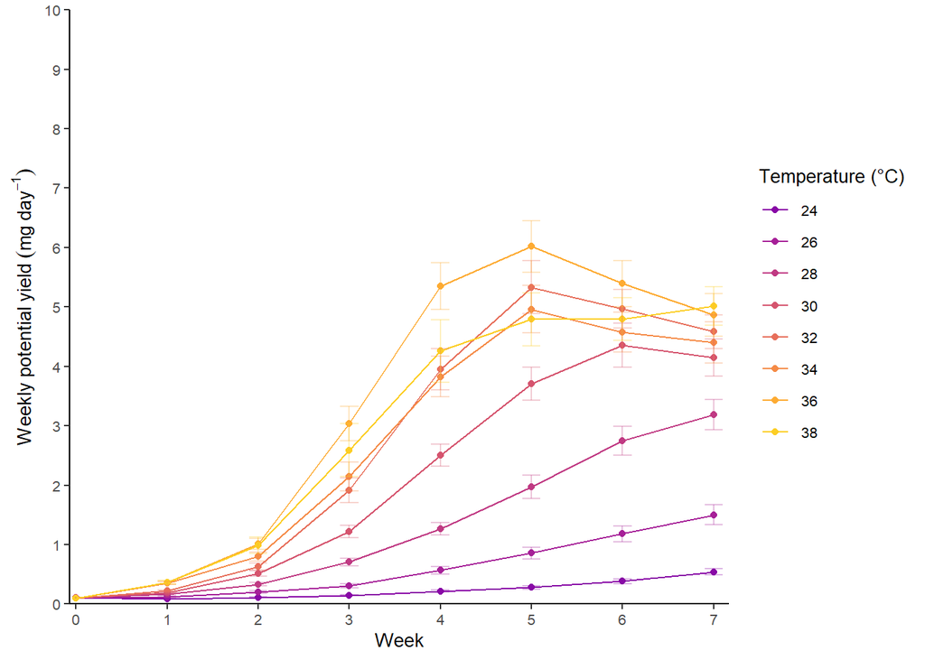

Figure 10: Weekly potential yield calculated for each individual throughout production.

```r
optimal_yield <- tpc %>%
  filter(temperature >= 24) %>%
  # Make experiment day non-0
  mutate(temperature = as.factor(temperature),
         week = week + 1) %>%
  distinct(temperature, mass, cricket, week) %>%
  group_by(cricket, week) %>%
  mutate(yield_index = mass / (week * 7)) %>%
  drop_na(yield_index) %>%
  group_by(week, temperature) %>%
  summarise(temp_yield = mean(yield_index),
            yield_se = sd(yield_index)/sqrt(n())) %>%
  filter(week <= 8) %>%
  mutate(week = week - 1)

optimal_yield_plot <- ggplot(optimal_yield, aes(week, temp_yield, colour = temperature)) +
  geom_line() +
  geom_point() +
  geom_errorbar(aes(y = temp_yield,
                    ymin = temp_yield - yield_se,
                    ymax = temp_yield + yield_se),
                width = 0.2, alpha = 0.3) +
  scale_colour_manual(name = "Temperature (°C)",
                      values = temperature_pal[-c(1,2)])  +
  scale_x_continuous(name = "Week",
                     limits = c(0, 7.1),
                     breaks = seq(0, 7, 1),
                     expand = c(0.01, 0)) +
  scale_y_continuous(name = expression(Weekly~potential~yield~(mg~day^-1)),
                     limits = c(0, 10),
                     breaks = seq(0, 10, 1),
                     expand = c(0, 0))

optimal_yield_plot
```

```r
optimal_yield_mod <- lm(temp_yield ~ week * temperature, optimal_yield)
anova(optimal_yield_mod) %>% kable()
```

Table 26: ANOVA testing the effect of time and temperature on yield.

|  | Df | Sum Sq | Mean Sq | F value | Pr(>F) |
| --- | --- | --- | --- | --- | --- |
| week | 1 | 121.67376 | 121.6737630 | 270.932959 | 0.0000000 |
| temperature | 7 | 70.48190 | 10.0688428 | 22.420457 | 0.0000000 |
| week:temperature | 7 | 29.92481 | 4.2749722 | 9.519151 | 0.0000002 |
| Residuals | 48 | 21.55641 | 0.4490918 | NA | NA |

# 11 Incubator temperature

The original inkbird for 28C broke and the recovered memory is different from the original download. The inkbird was replaced with the one from the 22C incubator.

Humidities were controlled by either bowls of water or silica gel.

```r
# List files
inkbird_files <- list.files("tpc/inkbirds/",
                            pattern = "_inkbird_",
                            full.names = TRUE)

# Import all files
inkbird <- lapply(FUN = read.csv, inkbird_files)
# Name the files based on file name: regrex all characters between "inkbirds/" and "_log"
names(inkbird) <- str_extract(inkbird_files,
                              pattern = "(?<=inkbirds/)(.*)(?=_log)")

# Tidy columns
inkbird <- inkbird %>%
  map(~ .x %>% select(-starts_with("MAC"))) %>%
  map(~ mutate(.x, Time = as.POSIXct(Time))) %>%
  map(~ .x %>% rename(Temperature = 2,
                      Humidity = 3)) %>%
  # Trim data to experiment
  map(~ filter(.x, Time >= as.POSIXct("2023-05-20 00:00:00") &
                 Time < as.POSIXct(Sys.Date()))) %>%
  bind_rows(., .id = "Target_temp") %>%  # add list name as ID column
  mutate(Target_temp = str_extract(Target_temp, "[^_]+") %>%
           as.numeric()) %>% # all characters before _
  left_join(., distinct(tpc_survival, incubator_number, temperature),
            by = c("Target_temp" = "temperature")) %>%
  mutate(Target_temp = as.character(Target_temp),
         row_id = row_number())
```

Temperature in incubator 15 (24 °C) spikes at 30 °C at 6:30 PM then returns to normal by midnight. These are removed.

```r
# Remove temperature spike from 24
rm_temp1 <- inkbird %>%
  filter(Target_temp == 24,
         Time < "2023-07-05 00:00:00",
         Time >= "2023-07-04 18:30:00") %>%
  pull(row_id)
# Remove old data from 28 after inkbird replaced
rm_temp2 <- inkbird %>%
  filter(Target_temp == 28,
         Time < "2023-08-05 00:00:00") %>%
    pull(row_id)
# Trim last data point in 34 after inkbird removed from incubator
rm_temp3 <- inkbird %>%
  filter(Target_temp == 34) %>%
  slice_head() %>%
  pull(row_id)

rm_temp <- c(rm_temp1, rm_temp2, rm_temp3)
inkbird <- filter(inkbird, !row_id %in% rm_temp)
```

```r
summary_inkbird <- inkbird %>%
  group_by(Target_temp, incubator_number) %>%
  summarise(temperature = mean(Temperature, na.rm = TRUE),
            temperature_sd = sd(Temperature, na.rm = TRUE),
            humidity = mean(Humidity, na.rm = TRUE),
            humidity_sd = sd(Humidity, na.rm = TRUE))

kable(summary_inkbird[,-2], digits = 3,
      col.names = c("Target temperature",
                    "Mean temperature (°C)",
                    "Temperature standard deviation (°C)",
                    "Mean relative humidity (%)",
                    "RH standard deviation (%)"))
```

Table 27: Summary statistics of incubator temperature and relative humidity.

| Target temperature | Mean temperature (°C) | Temperature standard deviation (°C) | Mean relative humidity (%) | RH standard deviation (%) |
| --- | --- | --- | --- | --- |
| 20 | 20.394 | 0.267 | 69.185 | 7.545 |
| 22 | 22.054 | 0.410 | 71.025 | 6.732 |
| 24 | 23.944 | 0.662 | 60.737 | 16.140 |
| 28 | 27.016 | 0.653 | 60.230 | 21.971 |
| 30 | 29.967 | 0.361 | 72.915 | 12.448 |
| 32 | 31.851 | 0.389 | 70.668 | 10.858 |
| 34 | 34.055 | 0.720 | 58.861 | 12.165 |
| 36 | 36.004 | 0.462 | 67.516 | 12.210 |
| 38 | 38.434 | 0.799 | 64.567 | 8.266 |

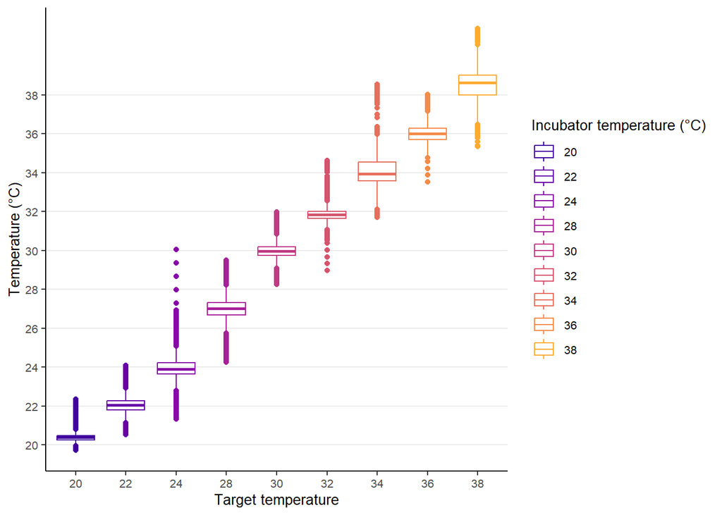

(a) Air temperature (°C)

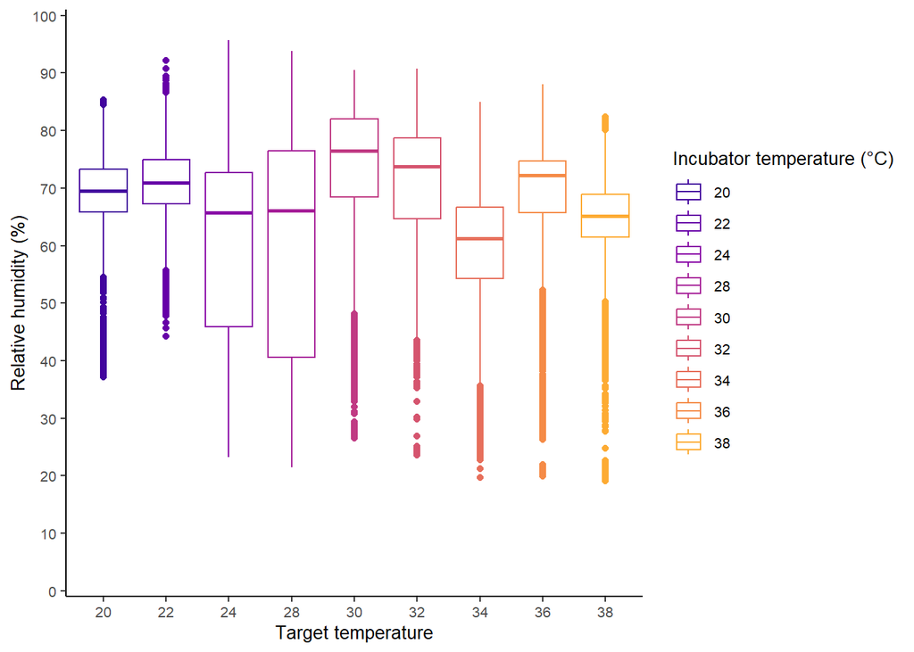

(b) Relative humidity (%)

Figure 11: Environmental conditions in the incubators.

```r
ggplot(inkbird, aes(Target_temp, Temperature, colour = Target_temp)) +
  geom_boxplot(fill = NA) +
  scale_colour_manual(name = "Incubator temperature (°C)",
                      values = temperature_pal) +
  scale_y_continuous(breaks =  seq(20, 38, 2)) +
  labs(x = "Target temperature",
       y = "Temperature (°C)") +
  theme(panel.grid.major.y = element_line())

ggplot(inkbird, aes(Target_temp, Humidity, colour = Target_temp)) +
  geom_boxplot(fill = NA) +
  scale_colour_manual(name = "Incubator temperature (°C)",
                      values = temperature_pal) +
  scale_y_continuous(limits = c(0, 100),
                     breaks = seq(0, 100, 10),
                     expand = expansion(c(0.01, 0.01))) +
  labs(x = "Target temperature",
       y = "Relative humidity (%)")
```

# 12 Manuscript Figures

Collate figures into multi-panel figures.

## 12.1 Figure 1

- Survival
- Growth curve
- Instar growth

```r
fig1 <- plot_grid(
  surv_plot + theme(legend.position = "none"),
  growth_curve +
    scale_x_continuous(name = "Week",
                       limits = c(0, 38),
                       breaks = seq(0, 38, 2),
                       expand = expansion(c(0, 0), c(0.5, 0))) +
    theme(legend.position = "none"),
  instar_curve + theme(legend.position = "none") ,
  ncol = 1,
  rel_heights = c(1.5, 1, 1.1),
  labels = "AUTO") %>%
  plot_grid(., get_legend(surv_plot), rel_widths = c(1, 0.2))

ggsave2(fig1, file = "tpc/output/fig1.png",
        dpi = 300,
        units = "cm",
        height = 17,
        width = 17)
```

## 12.2 Figure 2

- Adult mass (Female and Male)
- Development rate (Female and Male)
- Proportion survival to adulthood
- Longevity

```r
fig3 <- plot_grid(
  female_mass, male_mass,
  female_dev, male_dev,
  prop_adult_plot,
  lifespan_graph +
  annotate("text", label = "Temperature: F=49.4 P<0.01", x = 1, y = 300/11, vjust = 1, hjust = 0),
  ncol = 2,
  nrow = 3,
  labels = "AUTO",
  align = "v"
  )

ggsave2(fig3, file = "tpc/output/fig3.png",
        dpi = 300,
        units = "cm",
        height = 19,
        width = 19)
```

Figure 3 is reproductive output from Part 2.

## 12.3 Figure 4

- Potential yield
- Weekly yield

```r
fig4 <- plot_grid(individual_yield_plot,
                  optimal_yield_plot + theme(legend.position = "none"),
                  get_legend(optimal_yield_plot),
          ncol = 3,
          labels = c("A", "B", ""),
          align = "h",
          rel_widths = c(0.8, 0.8, 0.3))

ggsave2(fig4, file = "tpc/output/fig4.png",
        dpi = 300,
        units = "cm",
        height = 8,
        width = 17)
```